# Isoform switching — overview and QC

Author

Project

Published

July 30, 2026

## 1 Scope

This report summarizes **post-IsoformSwitchAnalyzeR** outputs: four datasets (HT and UT reference transcriptomes), gene-level collapse, and QC figures. Regenerate after running the pipeline and figure script from the project root.

**Pipeline order** (this report covers through QC; see README for `03`–`06`)

1. `Rscript scripts/01_load_data.R`
2. `Rscript scripts/02_gene_level_summary.R`
3. `Rscript scripts/02b_qc_snapshot.R` (table snapshots)
4. `Rscript scripts/02c_qc_figures.R` (this report’s figures)

**Render** (from project root is typical):

```bash
quarto render reports/isoform_switching_overview.qmd
```

The `setup` chunk locates the project by walking up until it finds `config/config.yml`, then sets `knitr`’s `root.dir` so `results/...` paths work.

## 2 Analysis design (from `config/config.yml`)

**Q1 — WT pre/post LPS (HT reference):** primary `T_HT` (THP1 anchor), supplementary `H_HT` (primary human).

**Q2 — UBL5 / U vs T (UT reference):** `U_UT` vs `T_UT`.

```r
library(knitr)
source("_setup.R")
```

```r
cat(reduction_caveat())
```

**ImportantInputs are already reduced to switching genes**

All 4 of 4 input ISA objects contain **only genes that already pass the gene-level q cutoff** (saved after `isoformSwitchTestDEXSeq(reduceToSwitchingGenes = TRUE)`).

Consequences for everything below: gene counts are *genes retained*, not *genes tested*; “present in the other dataset” means *retained in that saved object*, not *tested and non-significant*; and any percentage of genes has a denominator that was already selected on the outcome. Overlap between datasets is bounded by how many symbols survive in both objects. No enrichment test against this background is reported. See `docs/REVIEW_CHANGES.md`.

## 3 Input provenance

Recorded by `01_load_data.R` on every run, alongside `results/run_manifest.json` (git SHA, R and package versions, thresholds in force).

```r
red_path <- tab("input_object_reduction_check.csv")
if (file.exists(red_path)) {
  knitr::kable(
    read_tab("input_object_reduction_check.csv"),
    digits = 2,
    caption = "Per-dataset input check: are the saved ISA objects already reduced to switching genes?"
  )
} else {
  knitr::asis_output("_Run `Rscript scripts/01_load_data.R` to generate the input check._")
}
```

Table 1: Per-dataset input check: are the saved ISA objects already reduced to switching genes?

| dataset_key | dataset_label | n_isoforms | n_genes | n_genes_gene_q_significant | pct_genes_gene_q_significant | looks_reduced_to_switching_genes | has_unfiltered_context | n_genes_unfiltered | pct_genes_significant_unfiltered |
| --- | --- | --- | --- | --- | --- | --- | --- | --- | --- |
| T_HT | T_HT_anchor | 1543 | 216 | 216 | 100 | TRUE | TRUE | 10907 | 23.32 |
| H_HT | H_HT_supplementary | 3102 | 385 | 385 | 100 | TRUE | TRUE | 8160 | 20.53 |
| U_UT | U_UT | 966 | 127 | 127 | 100 | TRUE | TRUE | 11969 | 16.43 |
| T_UT | T_UT | 1769 | 248 | 248 | 100 | TRUE | TRUE | 11582 | 24.86 |

## 4 Gene-level snapshot

One row per gene: `02_gene_level_summary.R` collapses disagreeing gene symbols before grouping, so these are gene counts rather than row counts.

```r
require_outputs(
  "qc_snapshot_gene_level.csv",
  "Run scripts/02b_qc_snapshot.R first."
)
```

```
                                                                 qc_snapshot_gene_level.csv
"/Users/samkatz/projects/isoform-switch-pipeline/results/tables/qc_snapshot_gene_level.csv"
```

```r
qc <- read_tab("qc_snapshot_gene_level.csv")
knitr::kable(qc, digits = 2, caption = "Per-dataset gene counts and % with novel (PacBio) involvement")
```

Table 2: Per-dataset gene counts and % with novel (PacBio) involvement

| dataset | n_genes | n_switching_genes | n_novel_involved | pct_of_tested_genes_novel_involved | pct_of_switching_genes_novel_involved | pct_switching_genes |
| --- | --- | --- | --- | --- | --- | --- |
| H_HT_supplementary | 8160 | 169 | 101 | 1.24 | 59.76 | 2.07 |
| T_HT_anchor | 10907 | 95 | 47 | 0.43 | 49.47 | 0.87 |
| T_UT | 11582 | 118 | 60 | 0.52 | 50.85 | 1.02 |
| U_UT | 11969 | 62 | 33 | 0.28 | 53.23 | 0.52 |

## 5 Figures

All figures are written to `results/figures/` by `02c_qc_figures.R` and included below.

### 5.1 Gene-level

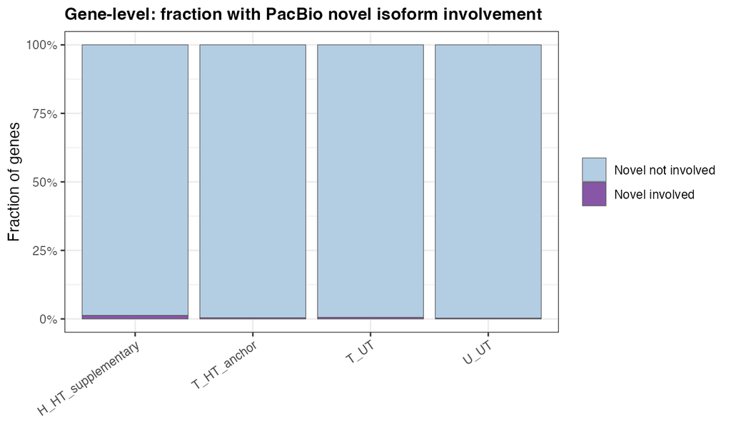

Figure 1: Stacked bar: fraction of genes with any switching involving a novel PacBio isoform

```r
knitr::include_graphics(proj_path("results/figures/fig_qc_novel_fraction_stacked.png"))
```

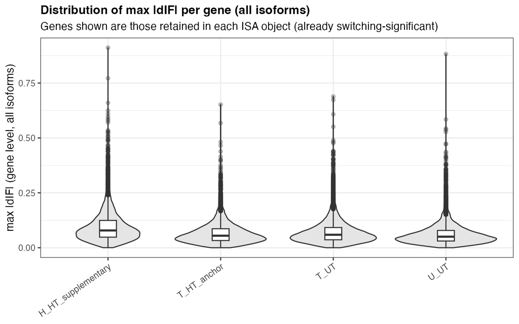

Figure 2: Max |dIF| per gene (violin + box)

```r
knitr::include_graphics(proj_path("results/figures/fig_qc_gene_max_abs_dif_violin.png"))
```

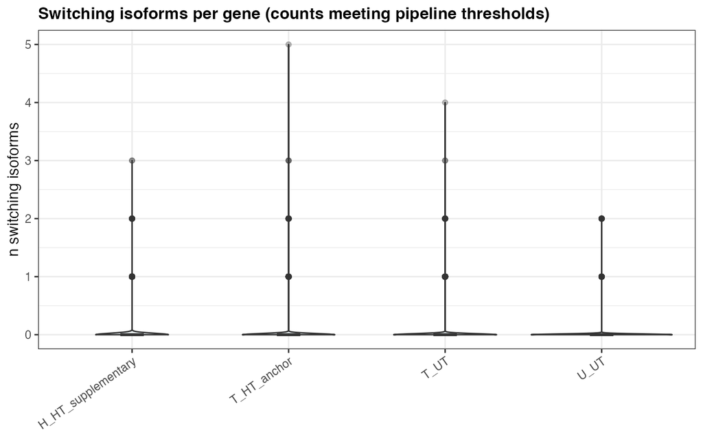

Figure 3: Number of switching isoforms per gene

```r
knitr::include_graphics(proj_path("results/figures/fig_qc_gene_n_switching_isoforms_violin.png"))
```

### 5.2 Isoform-level

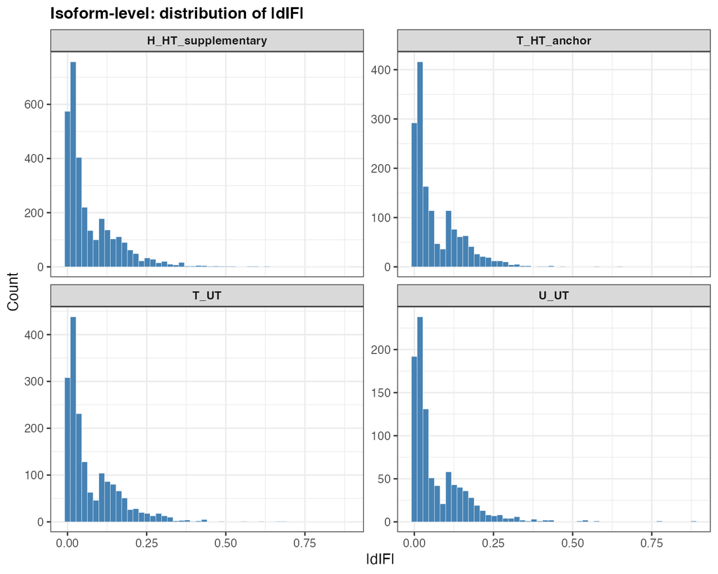

Figure 4: Distribution of |dIF| at isoform level (facets)

```r
p <- proj_path("results/figures/fig_qc_isoform_abs_dif_histogram.png")
if (file.exists(p)) {
  knitr::include_graphics(p)
} else {
  knitr::asis_output("_Isoform figures not found — run 01 and 02c._\n\n")
}
```

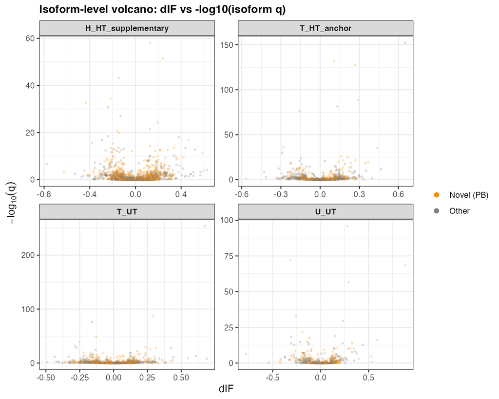

Figure 5: Volcano: dIF vs -log10(isoform q) (facets; novel PB highlighted)

```r
p <- proj_path("results/figures/fig_qc_isoform_volcano_by_dataset.png")
if (file.exists(p)) {
  knitr::include_graphics(p)
} else {
  knitr::asis_output("_Isoform figures not found — run 01 and 02c._\n\n")
}
```

## 6 Top candidate genes (automated)

```r
top_path <- proj_path("results/tables/qc_top10_genes_per_dataset.csv")
if (file.exists(top_path)) {
  top10 <- read.csv(top_path, check.names = FALSE, stringsAsFactors = FALSE)
  knitr::kable(top10, caption = "Top 10 genes per dataset (heuristic: n switching isoforms, then max |dIF|)")
} else {
  knitr::asis_output("_File missing — run scripts/02b_qc_snapshot.R._\n\n")
}
```

Table 3: Top 10 genes per dataset (heuristic: n switching isoforms, then max |dIF|)

| dataset | gene_id | gene_name | n_switching_isoforms | max_abs_dif_switching | max_abs_dif_all_isoforms | min_isoform_switch_q | novel_involved |
| --- | --- | --- | --- | --- | --- | --- | --- |
| H_HT_supplementary | XLOC_001925 | RABGAP1L | 3 | 0.4648000 | 0.4648000 | 0.0000000 | TRUE |
| H_HT_supplementary | XLOC_052000 | NIPAL2 | 3 | 0.2379667 | 0.2379667 | 0.0000000 | TRUE |
| H_HT_supplementary | XLOC_045300 | NCOA7 | 2 | 0.5224667 | 0.5224667 | 0.0000000 | FALSE |
| H_HT_supplementary | XLOC_025784 | IER2 | 2 | 0.4389333 | 0.4389333 | 0.0000000 | TRUE |
| H_HT_supplementary | XLOC_003522 | DOCK7 | 2 | 0.4146667 | 0.4146667 | 0.0007243 | TRUE |
| H_HT_supplementary | XLOC_022602 | SSTR2 | 2 | 0.3908667 | 0.3908667 | 0.0002724 | TRUE |
| H_HT_supplementary | XLOC_010685 | RHNO1 | 2 | 0.3792000 | 0.3792000 | 0.0000000 | TRUE |
| H_HT_supplementary | XLOC_030435 | PRKD3 | 2 | 0.3787333 | 0.3787333 | 0.0000000 | FALSE |
| H_HT_supplementary | XLOC_030175 | CMPK2 | 2 | 0.3368667 | 0.3368667 | 0.0000000 | TRUE |
| H_HT_supplementary | XLOC_021883 | TNFAIP1 | 2 | 0.2986667 | 0.2986667 | 0.0003561 | TRUE |
| T_HT_anchor | XLOC_046969 | IPCEF1 | 5 | 0.2899667 | 0.2899667 | 0.0000000 | TRUE |
| T_HT_anchor | XLOC_045300 | NCOA7 | 3 | 0.6521667 | 0.6521667 | 0.0000000 | TRUE |
| T_HT_anchor | XLOC_028123 | RSAD2 | 3 | 0.3671000 | 0.3671000 | 0.0000000 | TRUE |
| T_HT_anchor | XLOC_053671 | DDX58 | 3 | 0.2819667 | 0.2819667 | 0.0000000 | TRUE |
| T_HT_anchor | XLOC_030370 | RBKS | 2 | 0.4654000 | 0.4654000 | 0.0000000 | FALSE |
| T_HT_anchor | XLOC_031873 | MREG | 2 | 0.3184333 | 0.3184333 | 0.0000000 | FALSE |
| T_HT_anchor | XLOC_021587 | KDM6B | 2 | 0.3040667 | 0.3040667 | 0.0058784 | FALSE |
| T_HT_anchor | XLOC_005992 | IFIT1 | 2 | 0.2691000 | 0.2691000 | 0.0000000 | TRUE |
| T_HT_anchor | XLOC_011323 | IL23A | 2 | 0.2664000 | 0.2664000 | 0.0000000 | TRUE |
| T_HT_anchor | XLOC_015708 | RIN3 | 2 | 0.2494000 | 0.2494000 | 0.0013944 | FALSE |
| T_UT | XLOC_047270 | IPCEF1 | 4 | 0.2750000 | 0.2750000 | 0.0000000 | TRUE |
| T_UT | XLOC_036709 | CD86 | 3 | 0.4356667 | 0.4356667 | 0.0000000 | TRUE |
| T_UT | XLOC_054002 | DDX58 | 3 | 0.2854000 | 0.2854000 | 0.0000000 | TRUE |
| T_UT | XLOC_030548 | RBKS | 2 | 0.4408000 | 0.4408000 | 0.0000000 | FALSE |
| T_UT | XLOC_020026 | CCL22 | 2 | 0.3563333 | 0.3563333 | 0.0000000 | TRUE |
| T_UT | XLOC_028291 | RSAD2 | 2 | 0.3374000 | 0.3374000 | 0.0000000 | FALSE |
| T_UT | XLOC_011393 | IL23A | 2 | 0.3136333 | 0.3136333 | 0.0000000 | TRUE |
| T_UT | XLOC_021732 | KDM6B | 2 | 0.3039333 | 0.3039333 | 0.0054617 | FALSE |
| T_UT | XLOC_044425 | GFPT2 | 2 | 0.2798333 | 0.2798333 | 0.0001434 | TRUE |
| T_UT | XLOC_034994 | TIMP3 | 2 | 0.2690667 | 0.2690667 | 0.0000000 | TRUE |
| U_UT | XLOC_020026 | CCL22 | 2 | 0.8821667 | 0.8821667 | 0.0000000 | TRUE |
| U_UT | XLOC_011393 | IL23A | 2 | 0.5844667 | 0.5844667 | 0.0000000 | TRUE |
| U_UT | XLOC_025627 | FSTL3 | 2 | 0.4371667 | 0.4371667 | 0.0000000 | FALSE |
| U_UT | XLOC_017653 | AQP9 | 2 | 0.3242667 | 0.3242667 | 0.0000001 | TRUE |
| U_UT | XLOC_022194 | CCL4 | 2 | 0.3174667 | 0.3174667 | 0.0000000 | TRUE |
| U_UT | XLOC_032056 | MREG | 2 | 0.3087333 | 0.3087333 | 0.0000069 | FALSE |
| U_UT | XLOC_023567 | CCL3 | 2 | 0.2927667 | 0.2927667 | 0.0000000 | TRUE |
| U_UT | XLOC_033712 | RGS19 | 2 | 0.2885667 | 0.2885667 | 0.0000000 | FALSE |
| U_UT | XLOC_002833 | UTS2 | 2 | 0.2337000 | 0.2337000 | 0.0000000 | TRUE |
| U_UT | XLOC_049326 | FIGNL1 | 2 | 0.2121000 | 0.2121000 | 0.0016012 | FALSE |